# ID271 Final Exam

Grace Gaultier, Anton Roche, and Joel Chavez Ortiz

2026-03-13

### Methods

This analysis used a subset of data from participants of the Veterans Administration Normative Aging Study (NAS) which was established in 1963. It included men aged 21 to 80 years who were free of known chronic medical conditions by an initial screening. Longitudinal data on the men’s pulmonary function, heart rate variability, and blood pressure were measured every four years. During the follow-up period, black carbon (BC), temperature, and relative humidity were measured. The dataset used in this analysis consists of 968 subjects and 2454 observations. This study aimed to analyze the association between same-day temperature and BC exposure with systolic blood pressure (SBP), explore any effect heterogeneity caused by any covariates, and examine any potential lagged effects of temperature and BC exposure on SBP. Because the dataset contains repeated measurements for each participant, we fit a linear mixed-effects model with a random intercept for subject ID to account for within-subject correlation over time. Effect estimates and corresponding 95% confidence intervals were obtained from the mixed-effects model. Observations with missing covariate data were excluded using complete-case analysis. The mixed-effects model assumes a linear relationship between predictors and the outcome on the transformed scale, independence of observations conditional on random effects, normally distributed residual errors, normally distributed random effects, and constant residual variance. Additionally, the model assumes that random effects are independent of residual errors and that the random-effects structure appropriately captures the within-subject correlation. The outcome, SBP, was right skewed and was therefore log-transformed to better approximate normality of residuals and stabilize variance (Figure 1).

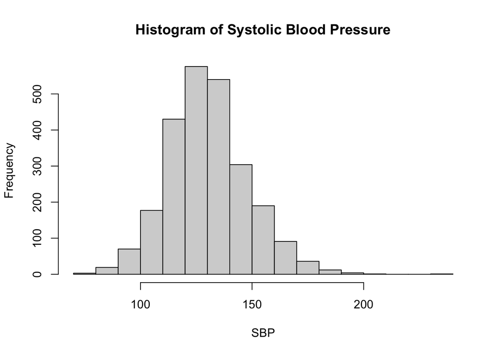

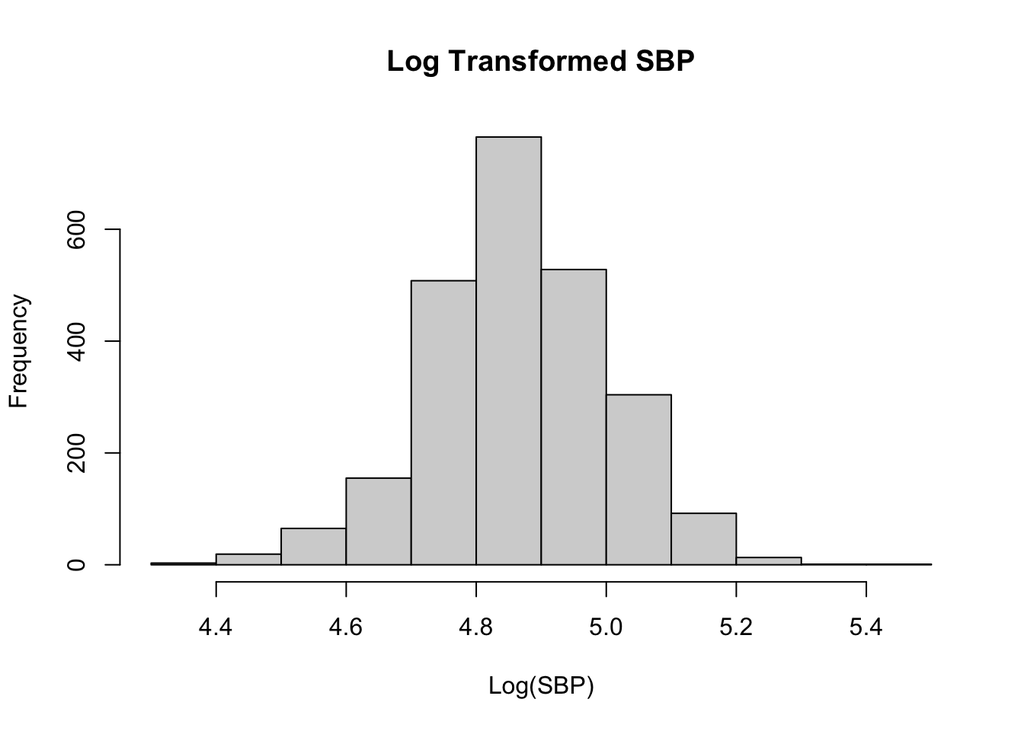

Same-day BC exposure and temperature were included as linear terms based on preliminary dose-response assessments and prior literature indicating approximately linear relationships within the observed exposure ranges (Figure 2).$^1$

**Figure 2. Dose Response Curves for Continuous Covariates and Log SBP**

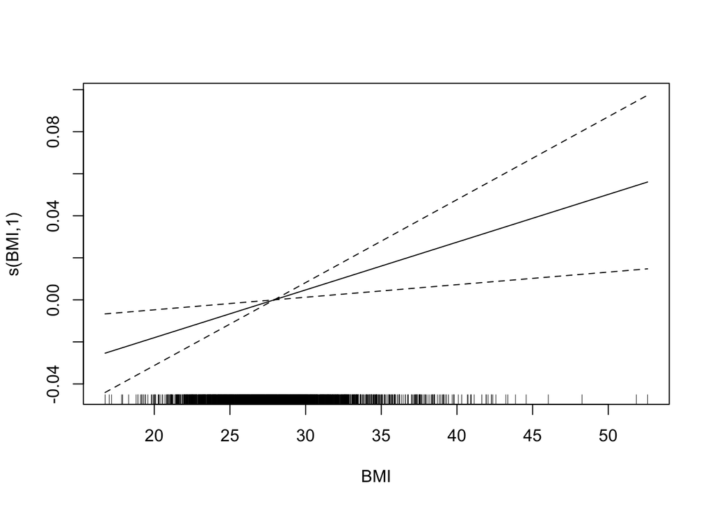

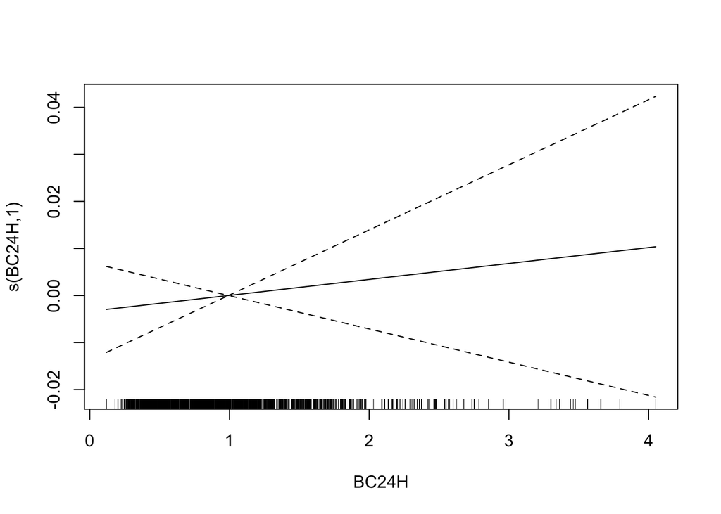

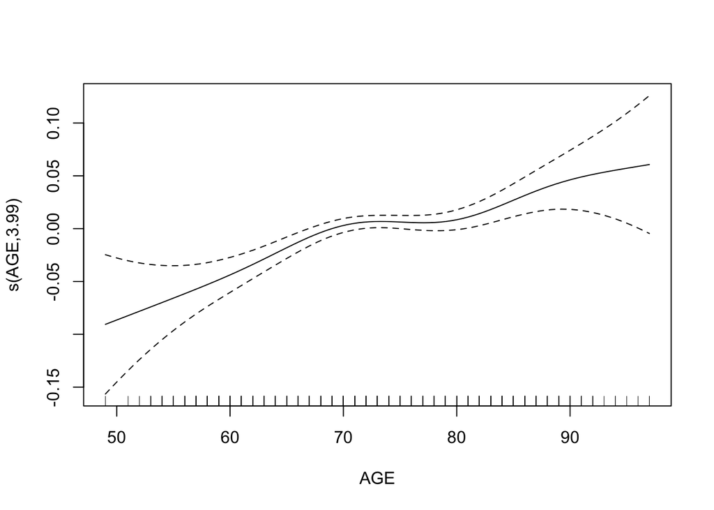

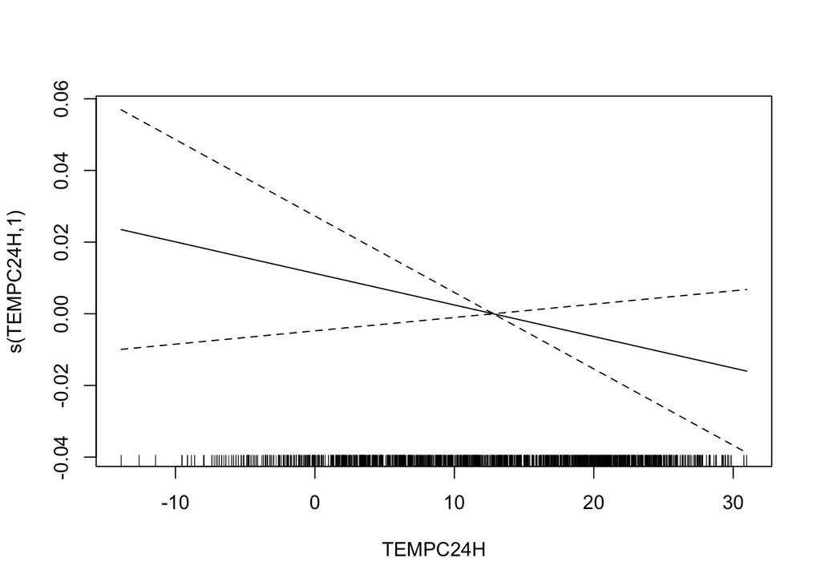

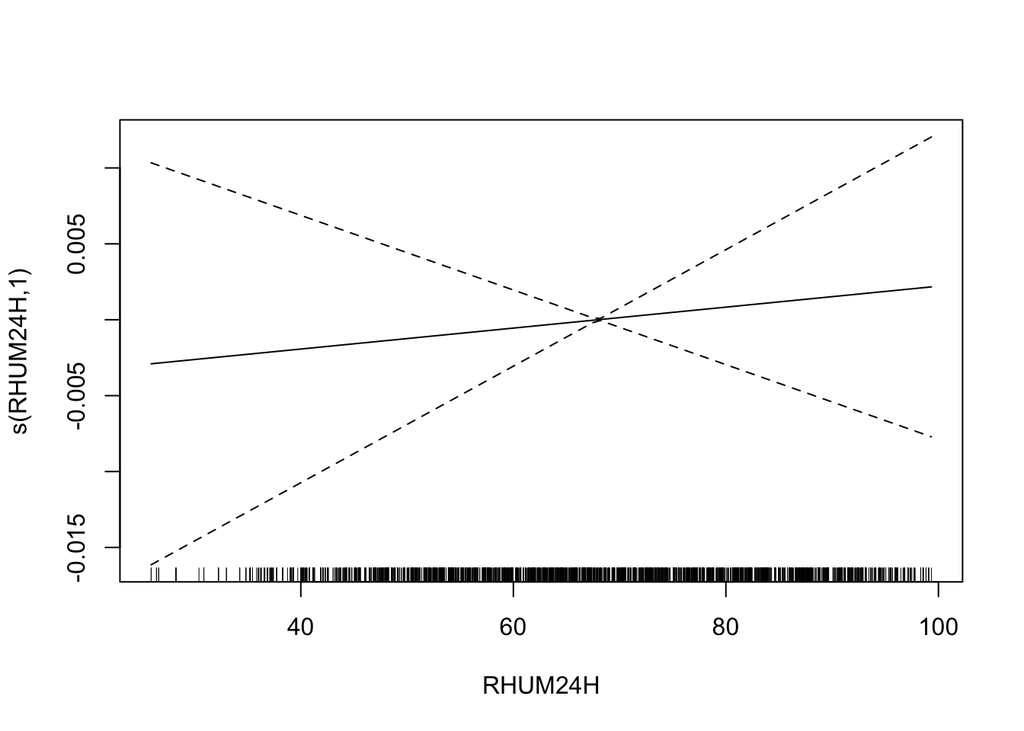

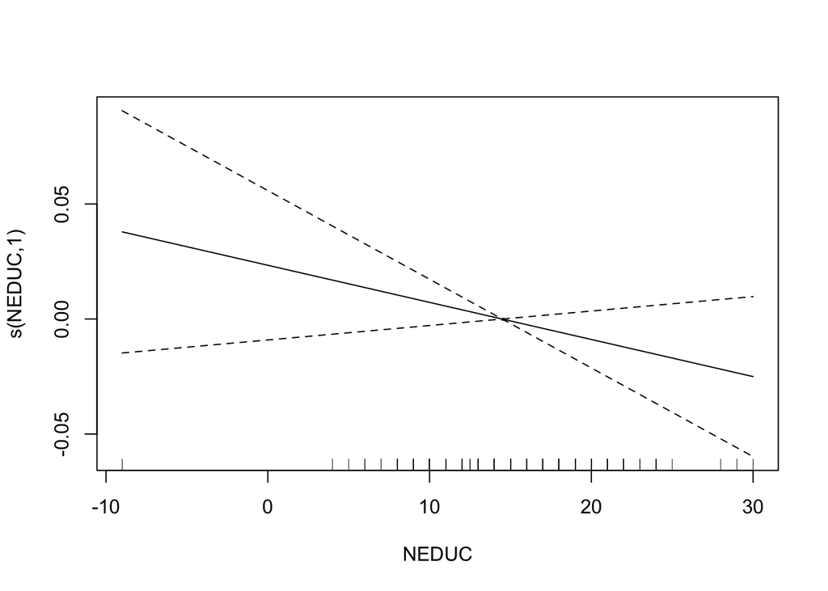

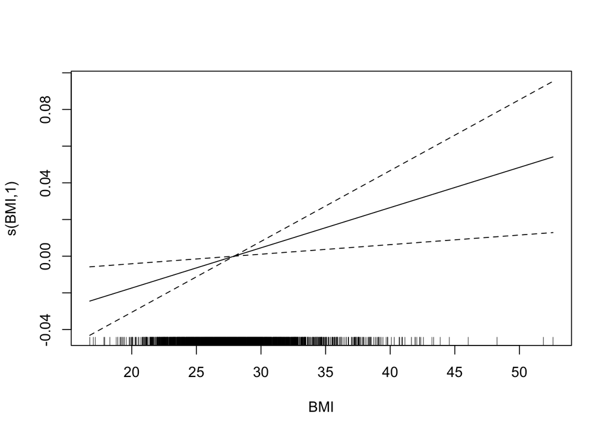

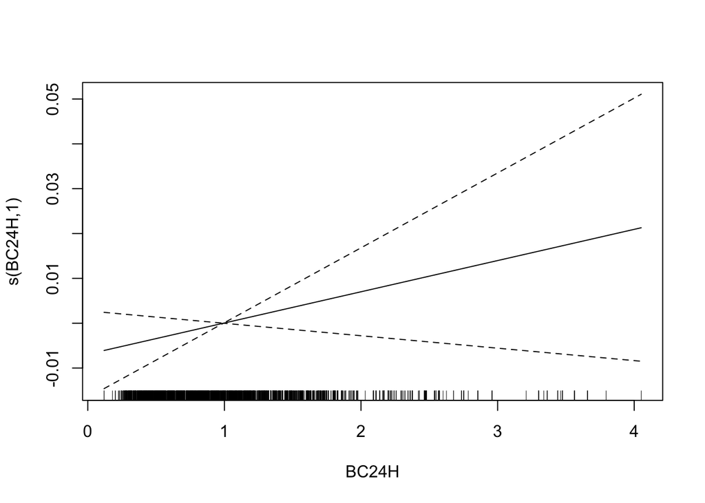

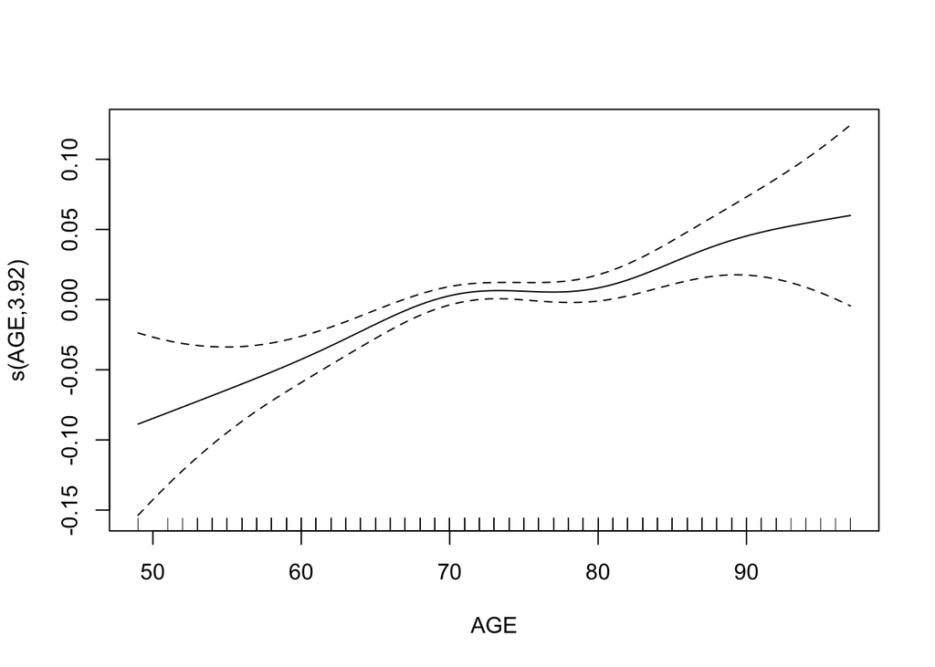

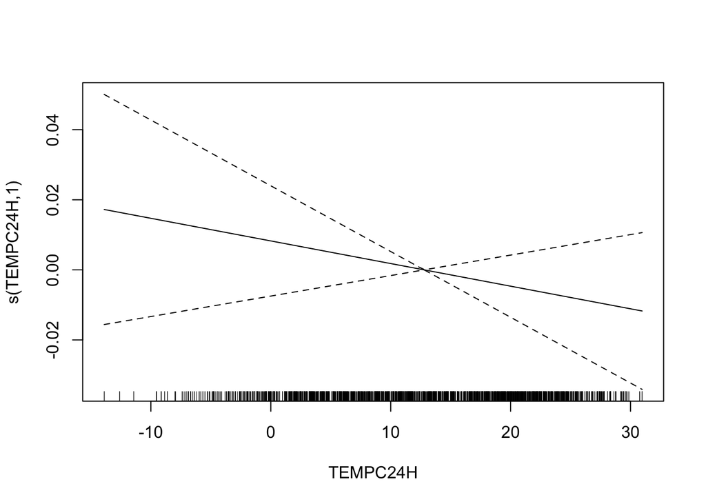

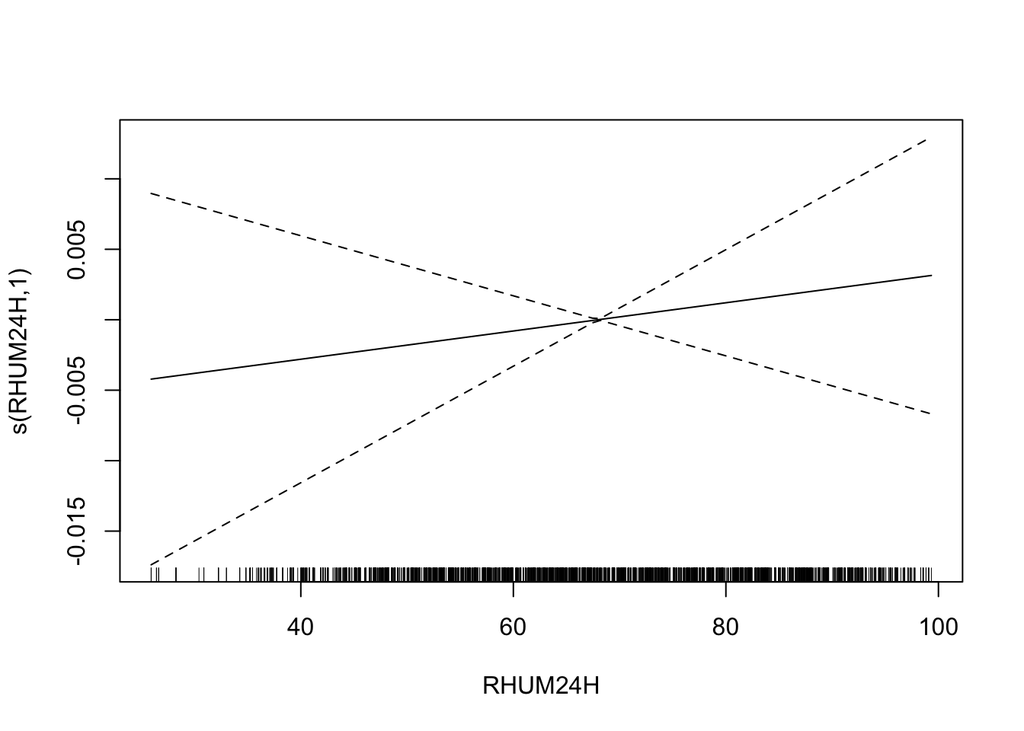

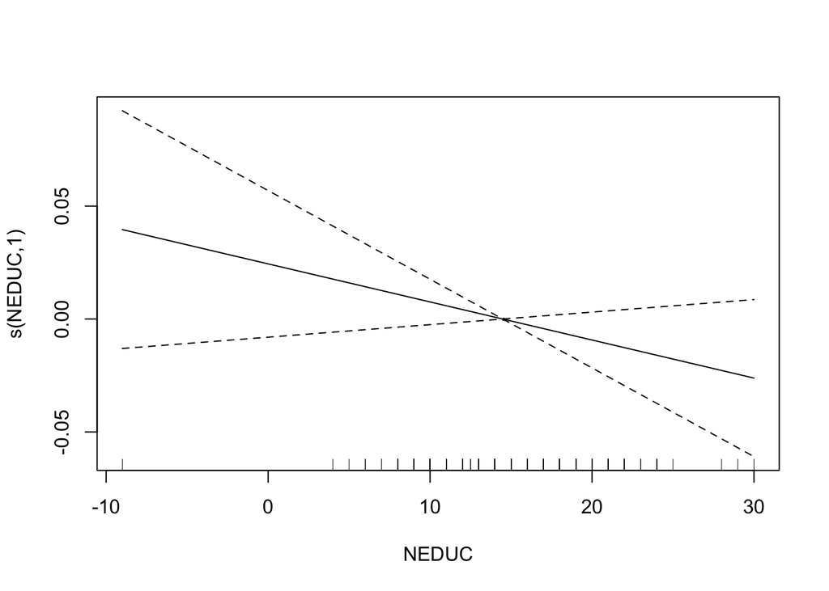

Age was modeled using a penalized spline to allow for potential nonlinear associations with SBP while avoiding overfitting (Figure 2).